# Introduction to Python and Programming for Data

## Assignment Part A

**Matriculation number:**

Note: Code cells for the answers have already been added to this notebook, but feel free to add additional markdown cells to describe your answers with text. In such markdown cells, write your answers in **bold** text to make them easily distinguishable from the exercises themselves.

### Exercise 1 (25 points)

The New York Times (NYT) APIs offer a rare free opportunity to analyse data since 1851 digitally (the year of the first issue of the paper) and thereby a multitude of historical events or also topics over time. You can e.g. use the "Article Search API" to search through all articles without obtaining their texts explicitly. Alternatively, you could use the "Archive API" which allows to download all article headlines and lead paragraphs/snippets for a given month (and through iteration potentially for a range of months or years). While this does not allow to obtain the full articles, it still allows to download a lot of textual data and thereby to do own textual analysis. There are also a range of other NYT APIs which you can find [here](https://developer.nytimes.com/apis) if these are of greater interest to you. If you click on a specific API, you also find detailed documentation about its endpoint format etc.

Think about a topic that you are interested in and use the NYT APIs to develop and present an initial analysis of the topic. A good starting point can be to think about whether content in the NYT APIs could be useful for your PhD thesis, or other research projects. You could then use this exercise as a starting point and explore the NYT APIs. A macroeconomist could e.g. track the word share of "inflation" over some years either with the Article search API or the Archive API (in this case e.g. with `pandas` or `sklearn` and only based on headlines and/or lead paragraphs) and illustrate some discussions of inflation through word clouds; an accounting researcher could e.g. look up specific historical newspaper discussions of accounting standards or reporting scandals; a finance researcher historical stock market crashes or bank runs; etc. The analysis can be based on basic quantitative text analysis, visualisations e.g. of keyword frequencies and time series, word clouds, written discussion, etc. Obtain the data from the APIs with `requests` and feel free to use any Python package which is helpful for the analysis.

Hint: The API notebook from the lecture can be a good starting point for this exercise. If you plan to use the Archive API to do the text analysis in Python, note that the main available text is contained in the headline, abstract, lead_paragraph, and/or snippet columns (depending on which month/year you download some of these will be empty or the same). Also note that a string for the headline can be found under the key `main` in the headline column of the data frame created in the lecture (i.e. a row in that column contains a dictionary).

```python
import requests
import time
import pandas as pd
```

```python
# Key obtained from https://developer.nytimes.com/
my_key = "MH8vw7JALnqiwDOZrnubJ4Pf2sAwcwas"
```

## 1.1 Article search API

```python
params = {"q": "subprime",
          "begin_date": "20080701",
          "end_date": "20081231",
          "api-key": my_key}
r = requests.get("https://api.nytimes.com/svc/search/v2/articlesearch.json",
                        params=params)
```

```python
data = r.json()
```

```python
data["response"].keys()
```

```
dict_keys(['docs', 'meta'])
```

```python
# meta data
data["response"]["meta"]["hits"]
```

```
2252
```

```python
def obtain_monthly_counts(search_term, key, start_year, end_year):

    params = {"q": search_term,
              "api-key": key}

    all_counts = []

    for year in range(start_year, end_year+1):

            for month in range(1,13):

                if month<10:
                    month = "0"+str(month)

                params["begin_date"] = f"{year}{month}01"
                params["end"] = f"{year}{month}31"

                r = requests.get("https://api.nytimes.com/svc/search/v2/articlesearch.json", params=params)
                data = r.json()
                count = data["response"]["meta"]["hits"]

                # Wait 7 seconds between requests to hace some buffer as only 10 requests
                # per minute are allowed
                time.sleep(7)

                all_counts.append(count)

    counts_series = pd.Series(all_counts)
    counts_series.index = pd.date_range(pd.to_datetime(f"{start_year}0101"), periods=(end_year-start_year+1)*12, freq='M')

    return counts_series
```

```python
mentions = obtain_monthly_counts(["inflation"], my_key, 1950, 2021)
```

```python
mention
```

```python
df = pd.DataFrame(mentions)
df
```

[output not shown]

[figure not shown]

```python
df.plot()
```

## 1.2 Archive API

```python
month = 1
year = 2021

url = f"https://api.nytimes.com/svc/archive/v1/{year}/{month}.json?api-key={my_key}"

r_archive = requests.get(url)
data_archive = r_archive.json()
```

```python
df = pd.DataFrame(data_archive["response"]["docs"])
df.shape
```

```
(7001, 20)
```

```python
df.head(2)
```

|  | abstract | web_url | snippet | lead_paragraph | print_section | print_page | source | multimedia | headline | keywords | pub_date | document_type | news_desk | section_name | byline | type_of_material | _id | word_count | uri | subsection_name |
| --- | --- | --- | --- | --- | --- | --- | --- | --- | --- | --- | --- | --- | --- | --- | --- | --- | --- | --- | --- | --- |
| 0 | Reasons to be hopeful about the Biden economy. | https://www.nytimes.com/2020/12/31/opinion/202... | Reasons to be hopeful about the Biden economy. | The next few months will be hell in terms of p... | A | 18 | The New York Times | [{'rank': 0, 'subtype': 'xlarge', 'caption': N... | {'main': 'Things Will Get Better. Seriously.',... | [{'name': 'persons', 'value': 'Biden, Joseph R... | 2021-01-01T00:00:09+0000 | article | OpEd | Opinion | {'original': 'By Paul Krugman', 'person': [{'f... | Op-Ed | nyt://article/ab590671-f1be-5b6d-8212-a7d18aab... | 882 | nyt://article/ab590671-f1be-5b6d-8212-a7d18aab... | NaN |
| 1 | The video shows a man raising something to his... | https://www.nytimes.com/2020/12/31/us/george-f... | The video shows a man raising something to his... | The Minneapolis Police Department released bod... | A | 17 | The New York Times | [{'rank': 0, 'subtype': 'xlarge', 'caption': N... | {'main': 'Minneapolis Police Release Body Came... | [{'name': 'persons', 'value': 'Idd, Dolal B', ... | 2021-01-01T00:16:53+0000 | article | National | U.S. | {'original': 'By Nicholas Bogel-Burroughs', 'p... | News | nyt://article/8f633850-09ab-53ff-8753-bc72eaba... | 861 | nyt://article/8f633850-09ab-53ff-8753-bc72eaba... | NaN |

```python
df.columns
```

```
Index(['abstract', 'web_url', 'snippet', 'lead_paragraph', 'print_section',
       'print_page', 'source', 'multimedia', 'headline', 'keywords',
       'pub_date', 'document_type', 'news_desk', 'section_name', 'byline',
       'type_of_material', '_id', 'word_count', 'uri', 'subsection_name'],
      dtype='object')
```

```python
liste = []

for i in df["headline"]:
    liste.append(i)

df_head = pd.DataFrame(liste)

liste_n = []

for i in df_head["main"]:
    liste_n.append(i)

liste_n

liste_n = "".join(liste_n)
```

```python
import re
```

```python
result = len(liste_n.split())

print("There are " + str(result) + " words.")

result_inflation = len(re.findall(r"[Ii]nflation|INFLATION", liste_n))

print("There are " + str(result_inflation) + " words with inflation.")
```

```
There are 54151 words.
There are 1 words with inflation.
```

```python
import wordcloud as wc
import matplotlib.pyplot as plt
```

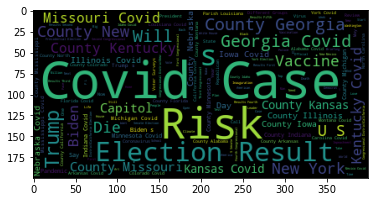

```python
wordcloud = wc.WordCloud().generate(liste_n)
plt.imshow(wordcloud)
```

### Exercise 2 (45 points)

This exercise is an independent project that allows you to illustrate and analyse data about a topic of your choice. Like in the previous exercise, a good approach can be to think of a topic that could be relevant as an illustration, section, or paper in your PhD research, and to try using this exercises as a starting point for later work.

The goal of the exericse is to first obtain data from APIs with requests, organise and store it in a SQLite database, and then examine and present the topic through computations and visualisations.

a) Read through this list of APIs mentioned in the lecture and choose any of the API(s) which you are particularly interested in (if you find a relevant API not contained in this list, that is of course also fine). Make sure that the API(s) you choose contain sufficient data for an analysis later on. Obtain the relevant data from your chosen API(s) through Python with requests rather than pre-built libraries. Then process the data with the typical pandas functionalities etc.

```python
url = "https://api.fiscaldata.treasury.gov/services/api/fiscal_service/v1/accounting/od/rates_of_exchange"
r_archive = requests.get(url)
data_archive = r_archive.json()
```

```python
url_1 = "https://api.fiscaldata.treasury.gov/services/api/fiscal_service/v1/accounting/od/rates_of_exchange?fields=country_currency_desc, exchange_rate,record_date&filter=country_currency_desc:in:(Euro Zone-Euro,Canada-Dollar)"
r_archive_1 = requests.get(url_1)
data_archive_1 = r_archive_1.json()

url_2 = "https://api.fiscaldata.treasury.gov/services/api/fiscal_service/v1/accounting/od/rates_of_exchange?fields=country_currency_desc, exchange_rate,record_date&filter=country_currency_desc:in:(Australia-Dollar,Bahrain-Dinar)"
r_archive_2 = requests.get(url_2)
data_archive_2 = r_archive_2.json()
```

```python
df_1 = pd.DataFrame(data_archive_1["data"])
df_1.head()
```

|  | country_currency_desc | exchange_rate | record_date |
| --- | --- | --- | --- |
| 0 | Canada-Dollar | 1.252 | 2022-03-31 |
| 1 | Canada-Dollar | 1.292 | 2022-06-30 |
| 2 | Canada-Dollar | 1.579 | 2002-12-31 |
| 3 | Canada-Dollar | 1.3 | 2019-12-31 |
| 4 | Canada-Dollar | 1.251 | 2005-06-30 |

```python
df_2 = pd.DataFrame(data_archive_2["data"])
df_2.head()
```

|  | country_currency_desc | exchange_rate | record_date |
| --- | --- | --- | --- |
| 0 | Australia-Dollar | 1.336 | 2022-03-31 |
| 1 | Australia-Dollar | 1.453 | 2022-06-30 |
| 2 | Australia-Dollar | 1.775 | 2002-12-31 |
| 3 | Australia-Dollar | 1.321 | 2005-06-30 |
| 4 | Australia-Dollar | 1.469 | 2003-09-30 |

```python
df_wide_1 = df_1.pivot(index=['country_currency_desc'], columns = ["record_date"], values = 'exchange_rate')

df_wide_1 = df_wide_1.T
df_wide_1
```

| country_currency_desc record_date | Canada-Dollar | Euro Zone-Euro |
| --- | --- | --- |
| 2001-03-31 | 1.532 | NaN |
| 2001-06-30 | 1.541 | NaN |
| 2001-09-30 | 1.549 | NaN |
| 2001-12-31 | 1.592 | NaN |
| 2002-03-31 | 1.604 | NaN |
| ... | ... | ... |
| 2021-06-30 | 1.239 | NaN |
| 2021-09-30 | 1.274 | NaN |
| 2021-12-31 | 1.277 | NaN |
| 2022-03-31 | 1.252 | 0.901 |
| 2022-06-30 | 1.292 | 0.962 |

67 rows × 2 columns

```python
df_wide_2 = df_2.pivot(index=['country_currency_desc'], columns = ["record_date"], values = 'exchange_rate')

df_wide_2 = df_wide_2.T
df_wide_2
```

| country_currency_desc record_date | Australia-Dollar | Bahrain-Dinar |
| --- | --- | --- |
| 2001-03-31 | 1.903 | NaN |
| 2001-06-30 | 1.979 | NaN |
| 2001-09-30 | 1.894 | NaN |
| 2001-12-31 | 1.955 | NaN |
| 2002-03-31 | 1.935 | NaN |
| ... | ... | ... |
| 2021-06-30 | 1.334 | NaN |
| 2021-09-30 | 1.391 | NaN |
| 2021-12-31 | 1.375 | NaN |
| 2022-03-31 | 1.336 | 0.377 |
| 2022-06-30 | 1.453 | 0.377 |

67 rows × 2 columns

```python
df_wide_1["Euro Zone-Euro"] = pd.to_numeric(df_wide_1["Euro Zone-Euro"])
df_wide_1["Canada-Dollar"] = pd.to_numeric(df_wide_1["Canada-Dollar"])
```

```python
df_wide_2["Australia-Dollar"] = pd.to_numeric(df_wide_2["Australia-Dollar"])
df_wide_2["Bahrain-Dinar"] = pd.to_numeric(df_wide_2["Bahrain-Dinar"])
```

b) Create a `SQLite` database (see `01-sqlite-database.ipynb` from Unit 7 as a reference), and store at least two tables in a well structured and thought through relational database (no need to store any data in the database that you do not need in your subsequent analysis).

```python
import sqlite3
import pandas as pd
import os

path = r"C:\Users\yyilmaz2"
os.chdir(path)
```

```python
df_wide_1.to_excel("Desktop/test_file_1.xlsx")
df_wide_2.to_excel("Desktop/test_file_2.xlsx")
```

```python
# Creates a database file if none exists and otherwise loads it
db = sqlite3.connect("test.sqlite")

# Load table with members of congress
congress_1 = pd.read_excel("Desktop/test_file_1.xlsx", index_col=0)
congress_2 = pd.read_excel("Desktop/test_file_2.xlsx", index_col=0)

# Add to database
congress_1.to_sql("congress_1", db, if_exists="replace")
congress_2.to_sql("congress_2", db, if_exists="replace")



# Test with simple query
# df = pd.read_sql("SELECT * FROM congress LIMIT 2", db)
df_1 = pd.read_sql("SELECT * FROM congress_1", db)
df_2 = pd.read_sql("SELECT * FROM congress_2", db)
```

c) Answer the following questions (i)-(iv) with SQL queries through `pd.read_sql()`:

(i) Return the column names of each table.

```python
df_1.columns
```

```
Index(['record_date', 'Canada-Dollar', 'Euro Zone-Euro'], dtype='object')
```

```python
df_2.columns
```

```
Index(['record_date', 'Australia-Dollar', 'Bahrain-Dinar'], dtype='object')
```

(ii) Return the total rows of each table.

```python
df_1.shape
```

```
(67, 3)
```

```python
#or
len(df_1.index)
```

```
67
```

```python
df_2.shape
```

```
(67, 3)
```

(iii) Return the first five rows of each table.

```python
df_1.head(5)
```

|  | record_date | Canada-Dollar | Euro Zone-Euro |
| --- | --- | --- | --- |
| 0 | 2001-03-31 | 1.532 | NaN |
| 1 | 2001-06-30 | 1.541 | NaN |
| 2 | 2001-09-30 | 1.549 | NaN |
| 3 | 2001-12-31 | 1.592 | NaN |
| 4 | 2002-03-31 | 1.604 | NaN |

```python
#or
df_1.iloc[0:5]
```

|  | record_date | Canada-Dollar | Euro Zone-Euro |
| --- | --- | --- | --- |
| 0 | 2001-03-31 | 1.532 | NaN |
| 1 | 2001-06-30 | 1.541 | NaN |
| 2 | 2001-09-30 | 1.549 | NaN |
| 3 | 2001-12-31 | 1.592 | NaN |
| 4 | 2002-03-31 | 1.604 | NaN |

```python
df_2.head(5)
```

|  | record_date | Australia-Dollar | Bahrain-Dinar |
| --- | --- | --- | --- |
| 0 | 2001-03-31 | 1.903 | NaN |
| 1 | 2001-06-30 | 1.979 | NaN |
| 2 | 2001-09-30 | 1.894 | NaN |
| 3 | 2001-12-31 | 1.955 | NaN |
| 4 | 2002-03-31 | 1.935 | NaN |

(iv) Demonstrate which of the tables can be joined. Return **only** the first five rows of the joined tables, and also return the total number of rows in the joined tables with a query.

```python
# Merge the data
df_final = pd.merge(df_1, df_2, how = "left", on = "record_date")
```

```python
# Show first five rows
df_final.head(5)
```

|  | record_date | Canada-Dollar | Euro Zone-Euro | Australia-Dollar | Bahrain-Dinar |
| --- | --- | --- | --- | --- | --- |
| 0 | 2001-03-31 | 1.532 | NaN | 1.903 | NaN |
| 1 | 2001-06-30 | 1.541 | NaN | 1.979 | NaN |
| 2 | 2001-09-30 | 1.549 | NaN | 1.894 | NaN |
| 3 | 2001-12-31 | 1.592 | NaN | 1.955 | NaN |
| 4 | 2002-03-31 | 1.604 | NaN | 1.935 | NaN |

```python
# Total number of rows
df_final.shape
```

```
(67, 5)
```

d) Now query the database with SQL to obtain the data for your main analysis. All subsequent analysis can be done with packages such as `pandas` etc. from here on (no need to use SQL further). Discuss and illustrate your data with suitable packages, e.g. through visualisations, computations in tabular form, quantitative text analysis, statistical models, and/or written text.

```python
# Add to database
df_final.to_sql("congress_final", db, if_exists="replace")
```

```python
# Read from database
df_3 = pd.read_sql("SELECT * FROM congress_final", db)
df_3
```

|  | index | record_date | Canada-Dollar | Euro Zone-Euro | Australia-Dollar | Bahrain-Dinar |
| --- | --- | --- | --- | --- | --- | --- |
| 0 | 0 | 2001-03-31 | 1.532 | NaN | 1.903 | NaN |
| 1 | 1 | 2001-06-30 | 1.541 | NaN | 1.979 | NaN |
| 2 | 2 | 2001-09-30 | 1.549 | NaN | 1.894 | NaN |
| 3 | 3 | 2001-12-31 | 1.592 | NaN | 1.955 | NaN |
| 4 | 4 | 2002-03-31 | 1.604 | NaN | 1.935 | NaN |
| ... | ... | ... | ... | ... | ... | ... |
| 62 | 62 | 2021-06-30 | 1.239 | NaN | 1.334 | NaN |
| 63 | 63 | 2021-09-30 | 1.274 | NaN | 1.391 | NaN |
| 64 | 64 | 2021-12-31 | 1.277 | NaN | 1.375 | NaN |
| 65 | 65 | 2022-03-31 | 1.252 | 0.901 | 1.336 | 0.377 |
| 66 | 66 | 2022-06-30 | 1.292 | 0.962 | 1.453 | 0.377 |

67 rows × 6 columns

```python
df_3.drop(columns=["index"], inplace = True)
df_3
```

|  | record_date | Canada-Dollar | Euro Zone-Euro | Australia-Dollar | Bahrain-Dinar |
| --- | --- | --- | --- | --- | --- |
| 0 | 2001-03-31 | 1.532 | NaN | 1.903 | NaN |
| 1 | 2001-06-30 | 1.541 | NaN | 1.979 | NaN |
| 2 | 2001-09-30 | 1.549 | NaN | 1.894 | NaN |
| 3 | 2001-12-31 | 1.592 | NaN | 1.955 | NaN |
| 4 | 2002-03-31 | 1.604 | NaN | 1.935 | NaN |
| ... | ... | ... | ... | ... | ... |
| 62 | 2021-06-30 | 1.239 | NaN | 1.334 | NaN |
| 63 | 2021-09-30 | 1.274 | NaN | 1.391 | NaN |
| 64 | 2021-12-31 | 1.277 | NaN | 1.375 | NaN |
| 65 | 2022-03-31 | 1.252 | 0.901 | 1.336 | 0.377 |
| 66 | 2022-06-30 | 1.292 | 0.962 | 1.453 | 0.377 |

67 rows × 5 columns

```python
df_3.dropna(inplace = True)
```

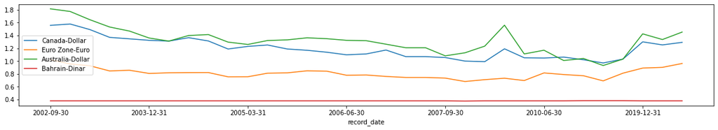

```python
df_3.plot(x = "record_date", kind = "line", figsize=(20,3))
```

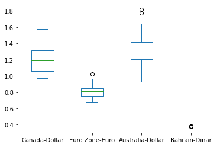

```python
df_3.plot.box()
```

[output not shown]

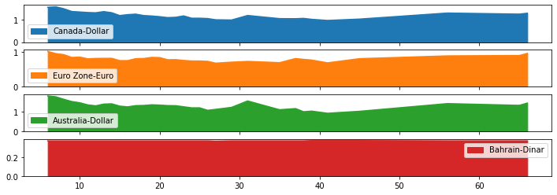

```python
df_3.plot.area(figsize=(12, 4), subplots=True)
```

```python
df_3.describe()
```

|  | Canada-Dollar | Euro Zone-Euro | Australia-Dollar | Bahrain-Dinar |
| --- | --- | --- | --- | --- |
| count | 33.000000 | 33.000000 | 33.000000 | 33.000000 |
| mean | 1.200000 | 0.807939 | 1.317242 | 0.377182 |
| std | 0.162364 | 0.081179 | 0.205020 | 0.001044 |
| min | 0.970000 | 0.680000 | 0.930000 | 0.374000 |
| 25% | 1.062000 | 0.753000 | 1.208000 | 0.377000 |
| 50% | 1.188000 | 0.810000 | 1.321000 | 0.377000 |
| 75% | 1.312000 | 0.845000 | 1.414000 | 0.377000 |
| max | 1.579000 | 1.020000 | 1.816000 | 0.380000 |

## Further Analysis, Global macroeconomic data

```python
# URATEUS - United States - Unemployment

df_ur = pd.read_csv(
'https://www.econdb.com/api/series/URATEUS/?format=csv',
index_col='Date', parse_dates=['Date'])
```

```python
df_ur = df_ur.rename(columns={"URATEUS":"Unemployment Rate"})
```

```python
df_ur.describe()
```

|  | Unemployment Rate |
| --- | --- |
| count | 895.000000 |
| mean | 5.744581 |
| std | 1.700629 |
| min | 2.500000 |
| 25% | 4.500000 |
| 50% | 5.500000 |
| 75% | 6.800000 |
| max | 14.700000 |

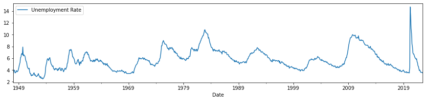

```python
df_ur.plot(figsize = (15,3))
```

```python
# RGDPPCUS - United States - Real GDP per capita

df_gdpc = pd.read_csv(
'https://www.econdb.com/api/series/RGDPPCUS/?format=csv',
index_col='Date', parse_dates=['Date'])
```

```python
df_gdpc = df_gdpc.rename(columns={"RGDPPCUS":"Real GDP per capita"})
```

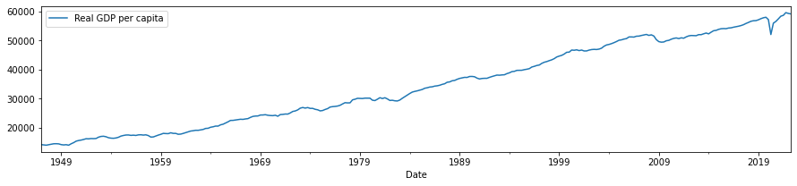

```python
df_gdpc.plot(figsize=(15,3))
```